- Sample Information
- Sequencing QC Summary
- ChIPseq QC Summary

# Azenta ChIP-Seq Sample Report

## 1. Sample Information

| Customer | Anders Ohman |
| --- | --- |
| Email | anders_ohman@brown.edu |
| QuoteNumber | 30-858293328 |
| Configuration |  |
| Sample | TA2-2m1 |

## 2. Sample Sequencing QC Summary

Raw BCL files generated by the sequencer were converted to FASTQ files for each sample using bcf2fastq v2.19. Raw sequencing data are evaluated with FastQC, a tool for assessing sequencing quality. Sequencing data from each read pair are plotted in red for read 1 and blue for read 2.

### 2.1 Per base sequence quality

Figure 2.1 shows the mean quality score (Q score) at each base position averaged across all reads. The x-axis represents base position in the read, and the y-axis represents the Q score. High quality samples have consistently high Q scores across the length of the read.

[interactive chart not shown]

Figure 2.1 Base quality score distribution

### 2.2 Overall quality score distribution

Figure 2.2 shows the distribution of average quality score of reads. The x-axis represents the Q score, and the y-axis shows the percentage of reads has equal or higher quality score to the x-axis.

[interactive chart not shown]

Figure 2.2 Reads quality score distribution

### 2.3 Per sequence GC content

Figure 2.3 shows the distribution of GC content across all reads. The x-axis represents %GC content, and the y-axis represents the proportion of all reads with a given GC content.

[interactive chart not shown]

Figure 2.3 Reads GC content distribution

## 3. ChIP-seq Sample QC Summary

### 3.1 Alignment Statistics

Sequencing adapters and low-quality bases were trimmed using Trimmomatic 0.38. Cleaned reads were then aligned to the reference genome /azngsfs/gwngs/data/projects/30-858293328/Rat-v6.cfg using bowtie2.

| Metrics | Value |
| --- | --- |
| Total Read Pairs | 28503454 |
| Read pairs after trimming | 28417640 |
| Read pairs concordantly aligned 1 time | 19002017 |
| Read pairs concordantly aligned &gt;1 times | 5908770 |
| Read pairs disconcordantly aligned 1 time | 19740 |

### 3.2 Post Processing Summary

Aligned reads were filtered using samtools 1.9 to keep alignments that (1) have a minimum mapping quality of 30, (2) are aligned concordantly, and (3) are the primary-called alignments. PCR or optical duplicates were marked using Picard 2.18.26 and removed. Prior to peak calling, reads mapping to mitochondria (mt) were called and filtered and reads mapping to unplaced contigs were removed. Chr filtering is shown in the table below.

| Metrics | Value |
| --- | --- |
| Read pairs after quality filtering | 19,253,717 |
| Read pairs after deduplication | 639,777 (3.32%) |

| Metrics | Value |
| --- | --- |
| Read pairs after deduplication | 639,777 |
| Deduplicated read pairs mapped to mitochondria | 2,764 (0.43%) |
| Deduplicated read pairs after chromosome filtering | 632,840 (98.92%) |

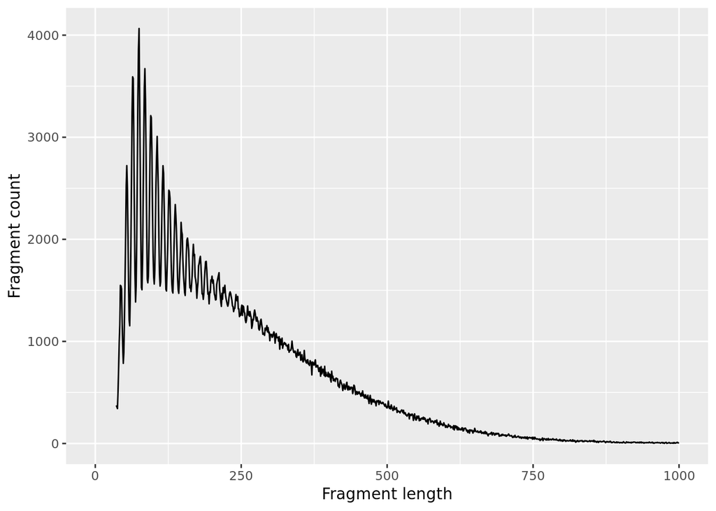

Figure 3.1 Insert size distribution of ChIP-seq library

### 3.3 Peak Calling Summary

MACS2 2.1.2 was used for peak calling to identify open chromatin regions. If a blacklist of artefactual regions (areas with extremely high or low-mappability) was available for the provided reference genome, called peaks were filtered for these regions to mitigate errors due to mappability.

| Metrics | Value |
| --- | --- |
| Fragments (read pairs) for analysis | 632,840 |
| Number of Peaks | 586 |
| Number of Peaks after Filtering | 586 |
| Number of fragments in peaks (Fip) | 0 (0%) |

- Azenta Life Sciences
- Next Generation Sequencing
- Email: ngs@azenta.com
- Phone: 908-222-0711 ext 1